# act_report

## ACT_REPORT

#### Data Wrangling Poject Report,

#### Presented By: Monica Iddah

#### August 11th, 2022

#### Introduction

The project is for Udacity Nano Degree Data Analysis Program, to test the students ability with data wrangling process.

It's basically for learning purpose, to help better the student's approach and style towards data wrangling.

The step by step procedure has apparently provided the student with a more thorough approach to data wranglinga, which provides the viewer with a better understanding of the process as each step is well detailed and broken down.

Using Python and its libraries, we gather data from a variety of sources and in a variety of formats, assess its quality and tidiness, then clean it.

For the analysis, the following files or dataset were provided:

1. Twitter_Archive
2. Twitter_Json
3. Image_predictions

NB: WeRateDogs is a Twitter account that rates people's dogs with a humorous comment about the dog. The ratings has a denominator of 10 with a numerator that has values greater than 10.

The rating numerator is higher because it was disxcovered that the dogs are great dogs.

[figure not shown]

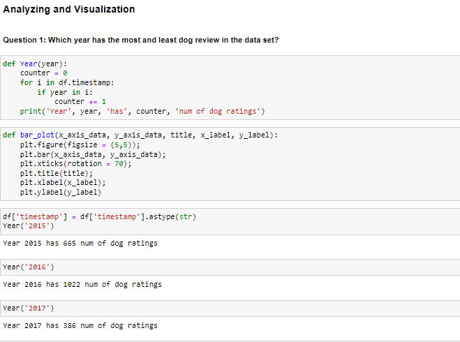

[figure not shown]

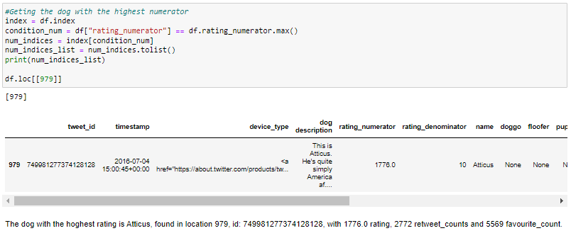

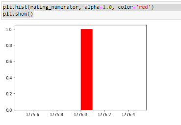

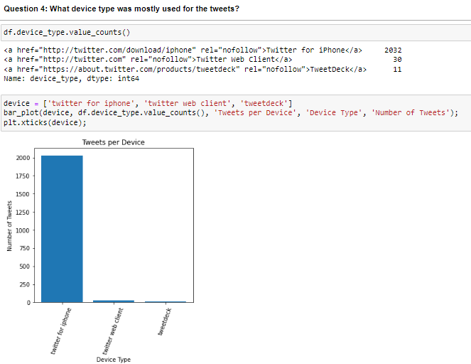